# Surgery Group 2

2026-02-27

## Load the libraries

```r
library(tidyverse)
library(shiny)
library(shinythemes)
library(janitor)
library(scales)
```

## Project Overview

This project analyzes whether surgery timing is associated with patient outcomes using data from 32,001 elective general surgery patients treated at Cleveland Clinic between 2005 and 2010.

Surgery Timing: A dataset from 32,001 elective general surgery patients who were treated at Cleveland Clinic between 2005 and 2010. It is well known that lack of sleep and heavy workloads can negatively affect performance. Hospital staff frequently face these challenges, especially during busier periods. Because of this, researchers wanted to determine whether the time at which surgery is performed has any impact on patient outcomes.

```r
surgery <- read_csv("data/surgery.csv") %>%
  clean_names()
names(surgery)
```

```
##  [1] "ahrq_ccs"            "age"                 "gender"
##  [4] "race"                "asa_status"          "bmi"
##  [7] "baseline_cancer"     "baseline_cvd"        "baseline_dementia"
## [10] "baseline_diabetes"   "baseline_digestive"  "baseline_osteoart"
## [13] "baseline_psych"      "baseline_pulmonary"  "baseline_charlson"
## [16] "mortality_rsi"       "complication_rsi"    "ccsmort30rate"
## [19] "ccscomplicationrate" "hour"                "dow"
## [22] "month"               "moonphase"           "mort30"
## [25] "complication"
```

1. Which race had the highest number of surgeries? #Daniella #Caucasians had the highest number of surgeries, indicating they make up the largest portion of patients undergoing these procedures.

```r
surgery %>%
  group_by(race) %>%
  summarise(
    n = n()
  ) %>%
  arrange(desc(n))
```

```
## # A tibble: 4 × 2
##   race                 n
##   <chr>            <int>
## 1 Caucasian        26488
## 2 African American  3790
## 3 Other             1243
## 4 <NA>               480
```

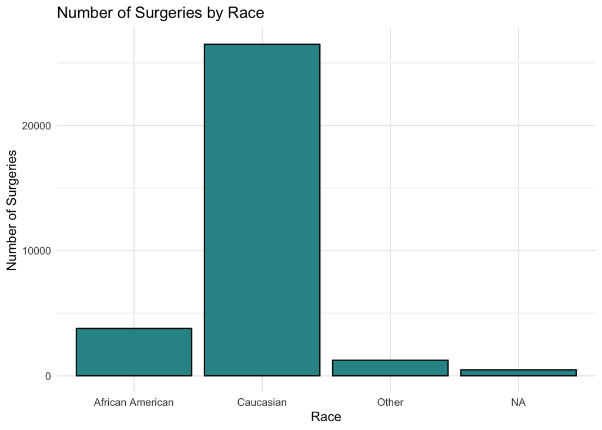

```r
surgery %>%
  count(race) %>%
  ggplot(aes(x=race, y=n))+
  geom_col(fill= "turquoise4", color ="black", alpha = 0.9) +
  labs(title = "Number of Surgeries by Race",
       x = "Race",
       y = "Number of Surgeries")+
  theme_minimal()
```

```r
surgery %>%
  group_by(age) %>%
  summarise(
    n = n()
  ) %>%
  arrange(desc(n))
```

```
## # A tibble: 813 × 2
##      age     n
##    <dbl> <int>
##  1  90     128
##  2  59.6   110
##  3  62     109
##  4  61.8   108
##  5  60.7   107
##  6  60.8   103
##  7  62.4   101
##  8  54.8   100
##  9  59.7   100
## 10  55.2    99
## # ℹ 803 more rows
```

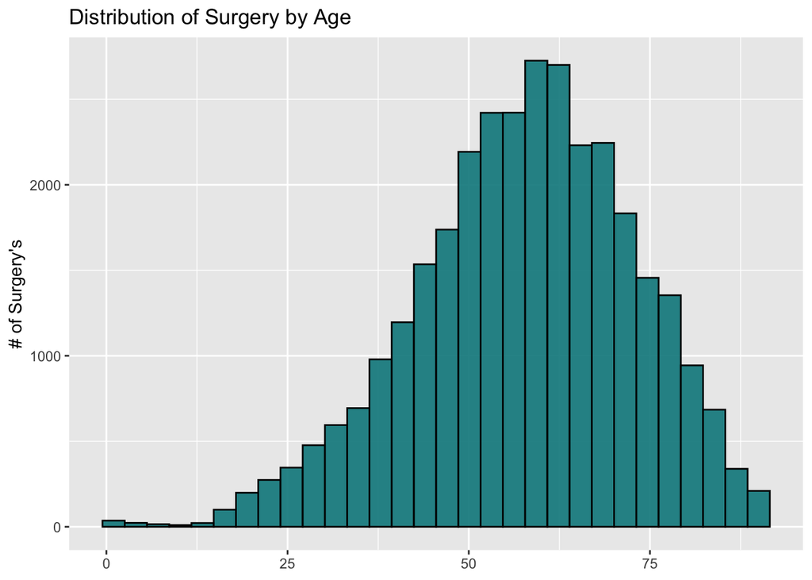

```r
surgery %>%
  ggplot(aes(x=age))+
  geom_histogram(fill= "turquoise4", color ="black", alpha = 0.9)+
  labs(title= "Distribution of Surgery by Age",
       x=NULL,
       y="# of Surgery's")
```

```r
surgery %>%
  filter(gender != "NA") %>%
  group_by(gender) %>%
  summarise(
    n = n()
  ) %>%
  arrange(desc(n))
```

```
## # A tibble: 2 × 2
##   gender     n
##   <chr>  <int>
## 1 F      17230
## 2 M      14768
```

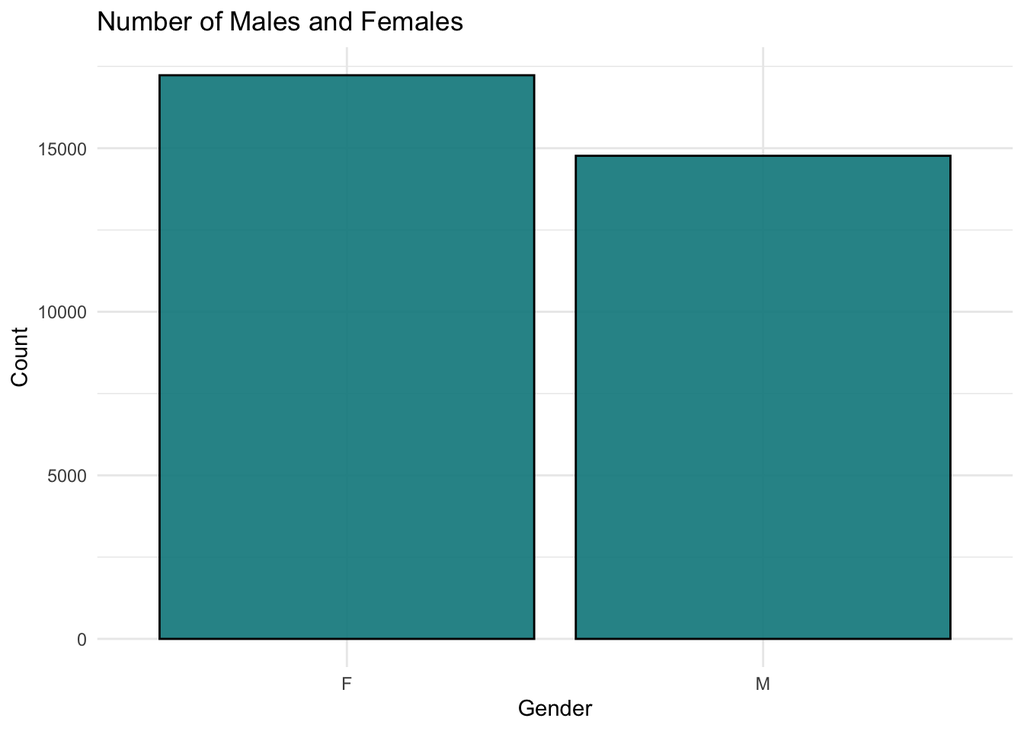

```r
 surgery %>%
  filter(gender != "NA") %>%
  count(gender) %>%
  ggplot(aes(x = gender, y = n, fill = gender)) +
  geom_col(fill= "turquoise4", color ="black", alpha = 0.9) +
  labs(title = "Number of Males and Females",
       x = "Gender",
       y = "Count")+
  theme_minimal()
```

4.Is mortality higher in males or females? #Aaliyah # Mortality is higher in males than in females, meaning more male patients died within 30 days after surgery.

```r
surgery %>%
  filter(gender != "NA") %>%
  count(gender, mort30)
```

```
## # A tibble: 4 × 3
##   gender mort30     n
##   <chr>  <chr>  <int>
## 1 F      No     17173
## 2 F      Yes       57
## 3 M      No     14687
## 4 M      Yes       81
```

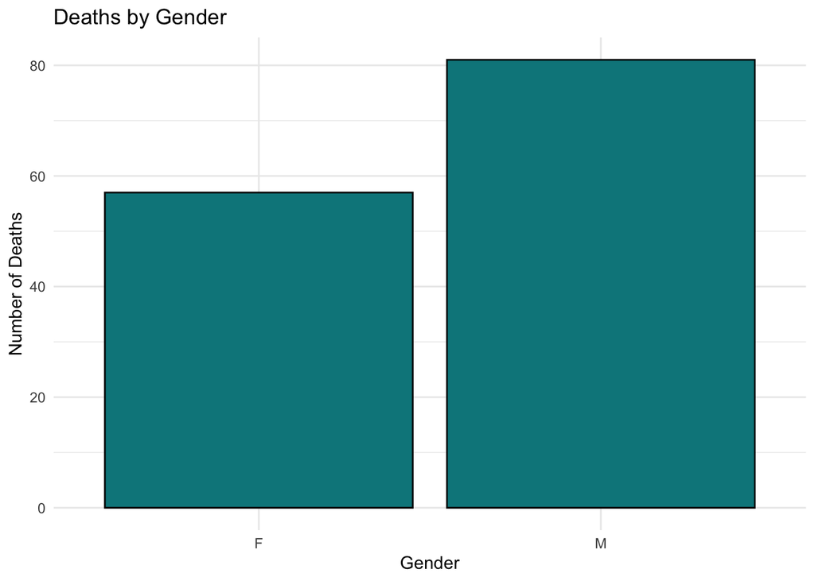

```r
surgery %>%
  filter(gender != "NA") %>%
  group_by(gender) %>%
  summarize(deaths = sum(mort30 == "Yes", na.rm = TRUE)) %>%
  ggplot(aes(gender, deaths)) +
  geom_col(fill="turquoise4", color="black") +
  labs( title="Deaths by Gender", x="Gender", y="Number of Deaths" ) +
  theme_minimal()
```

5.Does ASA status predict mortality? #Aaliyah # ASA statuses IV–VI have the highest mortality rates, although the overall rate is still relatively low at around 4%.

```r
surgery %>%
  filter(asa_status!="NA") %>%
  group_by(asa_status) %>%
  summarise(mortality_rate = mean(mort30 == "Yes", na.rm = T))
```

```
## # A tibble: 3 × 2
##   asa_status mortality_rate
##   <chr>               <dbl>
## 1 I-II             0.000695
## 2 III              0.00570
## 3 IV-VI            0.0455
```

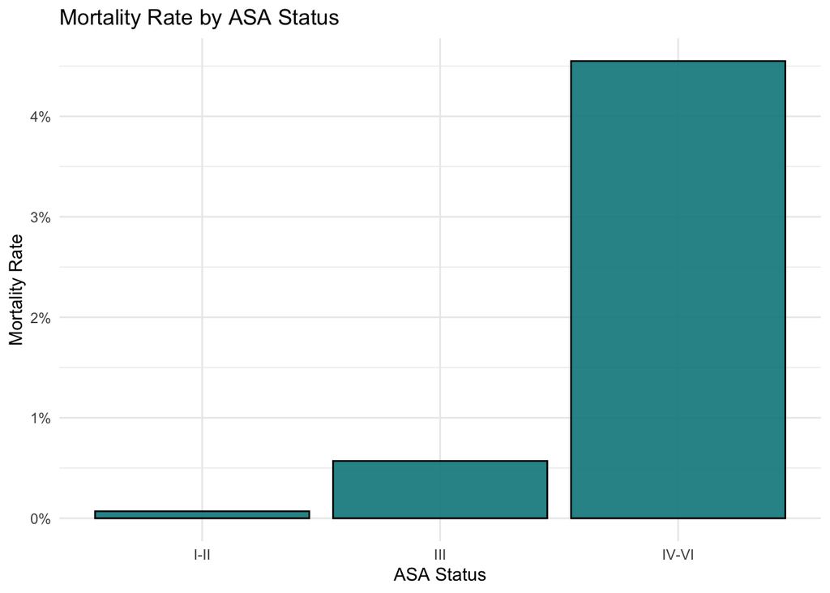

```r
surgery %>%
  filter(asa_status!="NA") %>%
  group_by(asa_status) %>%
  summarise(mortality_rate=mean(mort30=="Yes", na.rm=TRUE)) %>%
  ggplot(aes(asa_status, mortality_rate))+
  geom_col(fill="turquoise4", color="black", alpha=0.9)+
  scale_y_continuous(labels=scales::percent)+
  labs(title="Mortality Rate by ASA Status",
       x="ASA Status",
       y="Mortality Rate")+
  theme_minimal()
```

6. What is the distribution of age for each ASA status? Is there a relationship? #Aaliyah #The older someone seems to get, the higher the ASA status is, with the density graphs skewing further left the higher the ASA status levels go

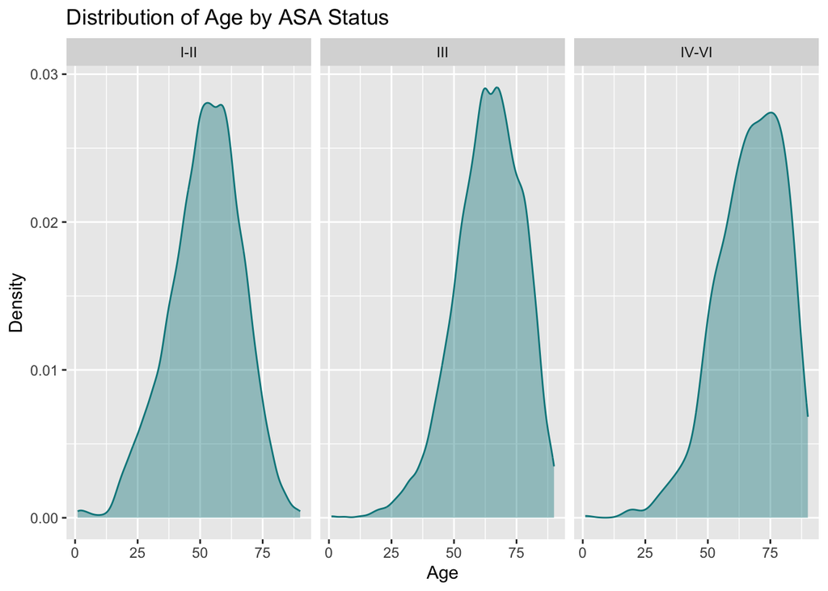

```r
surgery %>%
  filter(asa_status %in% c("I-II", "III", "IV-VI")) %>%
  ggplot(aes(x = age)) +
  geom_density(color = "turquoise4", fill = "turquoise4", alpha = 0.4) +
  facet_wrap(~ asa_status) +
  labs(
    title = "Distribution of Age by ASA Status",
    x = "Age",
    y = "Density"
  )
```

7.Do 30-day mortality rates differ by type of surgical procedure? #Aaliyah #Yes, 30-day mortality rates differ by type of surgical procedure, with procedures like colorectal resection and small bowel resection showing higher mortality rates compared to others with much lower rates.

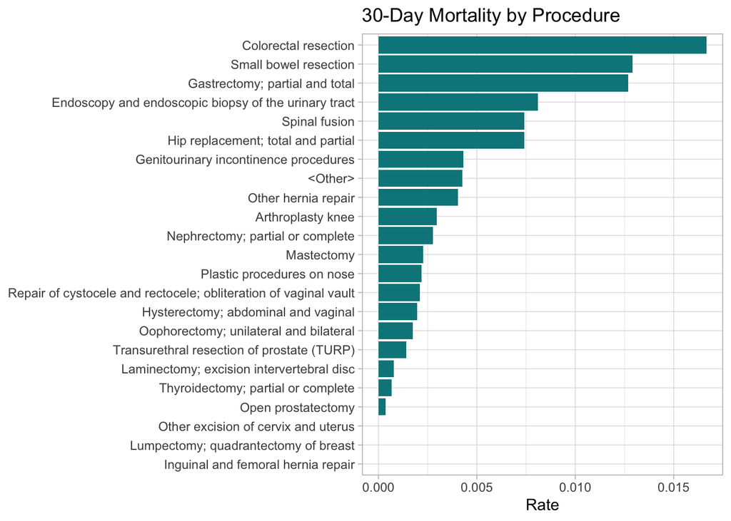

```r
surgery %>%
  group_by(ahrq_ccs) %>%
  summarise(ccsmort30rate = mean(ccsmort30rate, na.rm = TRUE)) %>%
  ggplot(aes(x = reorder(ahrq_ccs, ccsmort30rate), y = ccsmort30rate)) +
  geom_col(fill = "turquoise4") +
  coord_flip() +
  labs(title = "30-Day Mortality by Procedure",
       x = NULL,
       y = "Rate") +
  theme_light()
```

8.What month is mortality highest in and what month is the best for surgery? #Ale #January appears to have the highest mortality rate, while November appears to have the lowest mortality rate, meaning november is the best month to have surgery.

```r
surgery %>%
  filter(month != "NA") %>%
   mutate(month = factor(month, c("Jan","Feb","Mar","Apr","May","Jun","Jul","Aug","Sep","Oct","Nov","Dec"))) %>%
  group_by(month) %>%
  summarize(mortality = sum(mort30 == "Yes", na.rm = T)) %>%
  arrange(month)
```

```
## # A tibble: 12 × 2
##    month mortality
##    <fct>     <int>
##  1 Jan          19
##  2 Feb          17
##  3 Mar          12
##  4 Apr          12
##  5 May          10
##  6 Jun          14
##  7 Jul          12
##  8 Aug           9
##  9 Sep          16
## 10 Oct           8
## 11 Nov           5
## 12 Dec           4
```

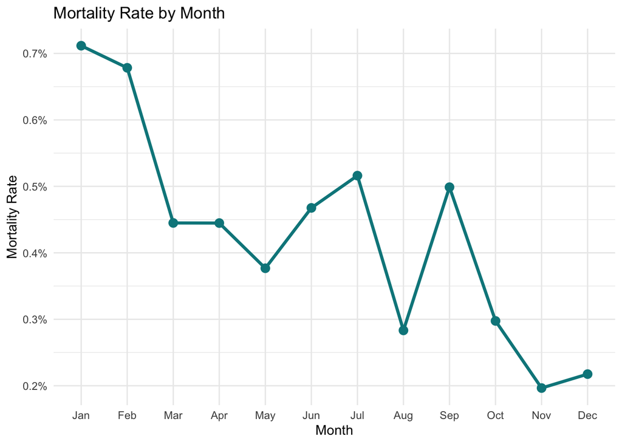

```r
surgery %>%
  filter(month!="NA") %>%
  mutate(month=factor(month,
                      c("Jan","Feb","Mar","Apr","May","Jun",
                        "Jul","Aug","Sep","Oct","Nov","Dec"))) %>%
  group_by(month) %>%
  summarise(mortality_rate=mean(mort30=="Yes", na.rm=TRUE)) %>%
  ggplot(aes(month, mortality_rate, group=1))+
  geom_line(color="turquoise4", linewidth=1.2)+
  geom_point(size=3, color="turquoise4")+
  scale_y_continuous(labels=scales::percent)+
  labs(title="Mortality Rate by Month",
       x="Month",
       y="Mortality Rate")+
  theme_minimal()
```

9.Is there any association between moon phase and mortality? #Ale # Mortality is highest during the full moon, though the variation across moon phases remains minimal.

```r
moon <- surgery %>%
  group_by(moonphase) %>%
  summarize(
    mortality_rate = mean(mort30 == "Yes", na.rm = T),
    n = n(),
    .groups = "drop")
```

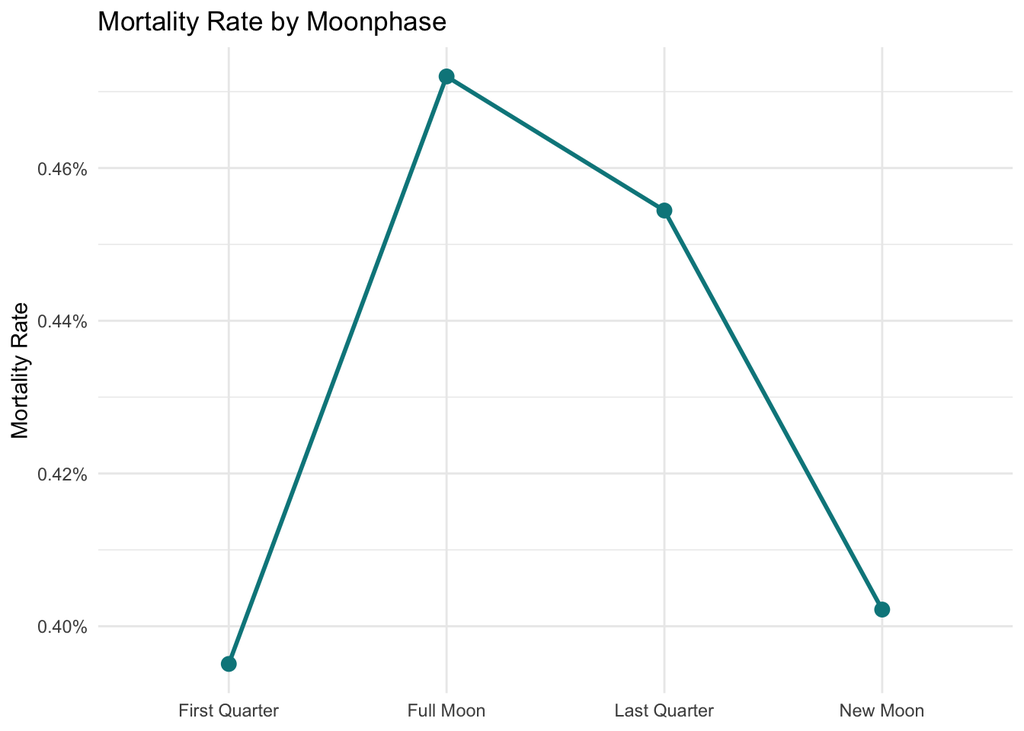

```r
moon %>%
  ggplot(aes(x = moonphase,
             y = mortality_rate,
             group = 1)) +
  geom_point(size = 3, color = "turquoise4") +
  geom_line(color = "turquoise4", linewidth = 1) +
  theme_minimal() +
  scale_y_continuous(labels = scales::percent) +
  labs(
    title = "Mortality Rate by Moonphase",
    x = NULL,
    y = "Mortality Rate"
  )
```

10. What surgery hour is associated with the highest mortality rate? #Ale #The mortality rate varies slightly depending on the hour of surgery. Surgeries performed earlier in the day tend to have lower mortality rates, while surgeries later in the afternoon show slightly higher mortality rates, suggesting that earlier surgery times may be associated with better patient outcomes.

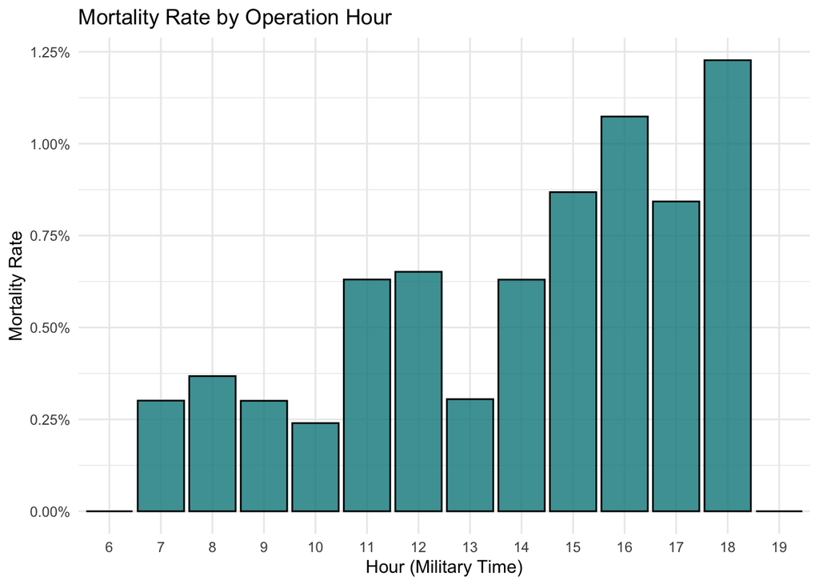

```r
surgery %>%
  mutate(hour_round = floor(hour)) %>%
  group_by(hour_round) %>%
  summarize(mortality_rate = mean(mort30 == "Yes", na.rm = TRUE)) %>%
  ggplot(aes(x = factor(hour_round), y = mortality_rate)) +
  geom_col(color = "black", fill = "turquoise4", alpha = 0.8) +
  scale_y_continuous(labels = scales::percent) +
  labs(
    title = "Mortality Rate by Operation Hour",
    x = "Hour (Military Time)",
    y = "Mortality Rate"
  ) +
  theme_minimal()
```

11.Does the day of the week that a surgery is performed affect patient mortality? #Ale # Mortality changes slightly across different days of the week, suggesting that timing within the week may have a small effect on patient outcomes.

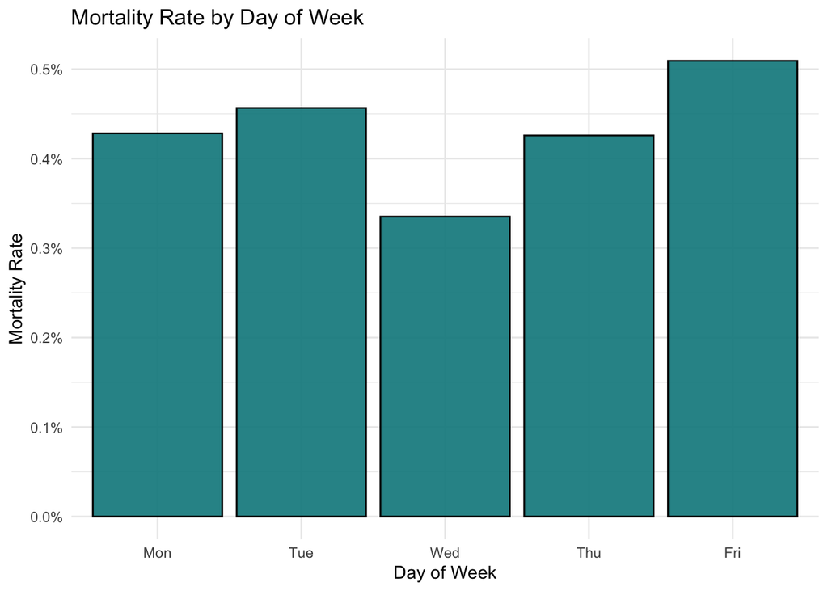

```r
surgery %>%
  filter(dow != "NA") %>%
  mutate(dow = factor(dow, levels = c("Mon","Tue","Wed","Thu","Fri"))) %>%
  group_by(dow) %>%
  summarise(mortality_rate = mean(mort30 == "Yes", na.rm = TRUE)) %>%
  ggplot(aes(x = dow, y = mortality_rate)) +
  geom_col(fill = "turquoise4", color = "black", alpha = 0.9) +
  scale_y_continuous(labels = scales::percent) +
  labs(
    title = "Mortality Rate by Day of Week",
    x = "Day of Week",
    y = "Mortality Rate"
  ) +
  theme_minimal()
```

12.Shiny App #Daniella

```r
library(shiny)

ui <- fluidPage(
  theme = shinytheme("flatly"),

  tags$head(
    tags$style(HTML("body { background-color: #f8f9fa;}
    .app-title {
    text-align:center;
    font-size: 34px;
    font-weight: 700;
    color: #d63384;
    margin-top: 15px;
    text-align:center;
    box-shadow: 2px 2px 8px rgba (0,0,0,0.08);
    }
    .stat-label {
    font-size:15px;
    color: #6c757d;
    }
    .stat-value {
    font-size: 24px;
    font-weight: bold;
    color: #d63384;
    }
    .sidebar-panel {
    background-color: #ffffff;
    padding:15px;
    border-radius: 12px;
    box-shadow: 2px 2px 8px rgba(0,0,0,0.08)
    }
    .main-panel-box{
    background-color: #ffffff;
    padding: 15px;
    border-radius: 12px;
    box-shadow: 2px 2px 8px rgba(0,0,0,0.08)
    }
    "))),

  div(class = "app-title", "Surgery Timing and Patient Outcomes"),

  fluidRow(
    column(4,
           div(class = "stat-box",
               div(class = "stat-label", textOutput("highest_label")),
               div(class = "stat-value", textOutput("highest_value")))),
    column(4,
           div(class = "stat-box",
               div(class = "stat-label", textOutput("lowest_label")),
               div(class = "stat-value", textOutput("lowest_value")))),
     column(4,
           div(class = "stat-box",
               div(class = "stat-label", "Overall Mortality Rate"),
               div(class = "stat-value", textOutput("overall_mortality"))))
  ),

    sidebarLayout(
      sidebarPanel(
        div(class = "sidebar-panel",
        h4("Plot Controls"),

        selectInput(
          "timing",
          "Choose Timing Variable",
          choices = c("Hour", "Day of Week", "Month", "Moonphase"),
          selected = "Hour"
        ),

        selectInput(
          "plot_color",
          "Choose Plot Color",
          choices = c("Pink" = "hotpink",
                      "Blue" = "steelblue",
                      "Green" = "darkgreen",
                      "Purple" = "purple",
                      "Orange" = "orange"),
          selected = "steelblue"
        ),

        checkboxInput("show_points", "Show Points on Graph", value = T)
      ),

      width = 3
    ),

    mainPanel(
      div(class = "main-panel-box",
          tabsetPanel(
            tabPanel(
              "Plot",
              br(),
              plotOutput("plot", width = "100%", height = "520px")
            ),
            tabPanel(
              "About",
              br(),
              h4("About Our App"),
              p("This app explores the relationship between different time variables during surgery and patient mortality."),
              tags$ul(
                tags$li("Hour"),
                tags$li("Day of Week"),
                tags$li("Month"),
                tags$li("Moonphase")
              ),
              p("Use the sidebar to toggle variables and colors")
            )
          )
      ),
      width = 9
    )
  )
)

server <- function(input, output, session) {

  summary_data <- reactive({

  if (input$timing == "Hour") {
    surgery %>%
      mutate(category = floor(hour)) %>%
      group_by(category) %>%
      summarise(
        mortality_rate = mean(mort30 == "Yes", na.rm = TRUE),
        .groups = "drop"
      )

  } else if (input$timing == "Day of Week") {
    surgery %>%
      mutate(category = factor(dow, levels = c("Mon", "Tue", "Wed", "Thu", "Fri"))) %>%
      group_by(category) %>%
      summarise(
        mortality_rate = mean(mort30 == "Yes", na.rm = TRUE),
        .groups = "drop"
      )

  } else if (input$timing == "Month") {
    surgery %>%
      filter(!is.na(month), month != "NA") %>%
      mutate(category = factor(month, levels = c(
        "Jan", "Feb", "Mar", "Apr", "May", "Jun",
        "Jul", "Aug", "Sep", "Oct", "Nov", "Dec"
      ))) %>%
      group_by(category) %>%
      summarise(
        mortality_rate = mean(mort30 == "Yes", na.rm = TRUE),
        .groups = "drop"
      )

  } else {
    surgery %>%
      filter(!is.na(moonphase), moonphase != "NA") %>%
      mutate(category = moonphase) %>%
      group_by(category) %>%
      summarise(
        mortality_rate = mean(mort30 == "Yes", na.rm = TRUE),
        .groups = "drop"
      )
  }
})

  hour_data <- reactive({
    surgery %>%
      mutate(hour_round = floor(hour)) %>%
      group_by(hour_round) %>%
      summarize(mortality_rate = mean(mort30 == "Yes", na.rm = T), .groups = "drop")
  })

output$highest_label <- renderText({
  paste("Highest Mortality", input$timing)
})

output$lowest_label <- renderText({
  paste("Lowest Mortality", input$timing)
})

output$highest_value <- renderText({
  data <- summary_data()

  highest <- data %>%
    filter(mortality_rate == max(mortality_rate, na.rm = TRUE))

  value <- as.character(highest$category[1])

  if (input$timing == "Hour") {
    paste0(value, ":00")
  } else {
    value
  }
})

output$lowest_value <- renderText({
  data <- summary_data()

  lowest <- data %>%
    filter(mortality_rate == min(mortality_rate, na.rm = TRUE))

  value <- as.character(lowest$category[1])

  if (input$timing == "Hour") {
    paste0(value, ":00")
  } else {
    value
  }
})

    output$overall_mortality <- renderText({
    rate <- mean(surgery$mort30 == "Yes", na.rm = T)
      scales::percent(rate, accuracy = 0.01)
    })

    output$plot <- renderPlot({

      if (is.null(input$timing) || input$timing == "") {
        return(NULL)
      }

      if (input$timing == "Hour") {
        plot_data <- surgery %>%
          mutate(hour_round = floor(hour)) %>%
          group_by(hour_round) %>%
          summarize(mortality_rate = mean(mort30 == "Yes", na.rm = T), .groups = "drop")

        ggplot(plot_data, aes(x = factor(hour_round), y = mortality_rate))+
          geom_col(fill = input$plot_color, color = "black", alpha = 0.9)+
          scale_y_continuous(labels = percent)+
          labs( title = "Mortality Rate by Operation Hour",
                x = "Hour",
                y = "Mortality Rate")+
          theme_minimal()+
          theme(
            plot.title = element_text(face = "bold", size = 18, hjust = 0.5, color = "maroon"),
            axis.title = element_text(face = "bold"),
            panel.grid.minor = element_blank()
          )
      }

      else if (input$timing == "Day of Week")
      {
        plot_data <- surgery %>%
          mutate(dow = factor(dow, levels = c("Mon", "Tue", "Wed", "Thu", "Fri"))) %>%
          group_by(dow) %>%
          summarize(mortality_rate = mean(mort30 == "Yes", na.rm = T), .groups = "drop")

         ggplot(plot_data, aes(x = dow, y = mortality_rate))+
          geom_col(fill = input$plot_color, color = "black", alpha = 0.9)+
          scale_y_continuous(labels = percent)+
          labs( title = "Mortality Rate by DOW",
                x = "Day of Week",
                y = "Mortality Rate")+
          theme_minimal()+
          theme(
            plot.title = element_text(face = "bold", size = 18, hjust = 0.5, color = "maroon"),
            axis.title = element_text(face = "bold"),
            panel.grid.minor = element_blank()
          )
         }
      else if (input$timing == "Month")
      {
        plot_data <- surgery %>%
          filter(month != "NA") %>%
          mutate(month = factor(month, levels = c("Jan", "Feb", "Mar", "Apr", "May", "June",
                                          "Jul", "Aug", "Sep", "Oct", "Nov", "Dec"))) %>%
          group_by(month) %>%
          summarize(mortality_rate = mean(mort30 == "Yes", na.rm = T), .groups = "drop")

         p <- ggplot(plot_data, aes(x = month, y = mortality_rate, group = 1))+
          geom_line(color = input$plot_color)

         if (input$show_points){
           p <- p + geom_point (size = 4, color = input$plot_color)
         }

         p+
          scale_y_continuous(labels = percent)+
          labs( title = "Mortality Rate by Month",
                x = "Month",
                y = "Mortality Rate")+
          theme_minimal()+
          theme(
            plot.title = element_text(face = "bold", size = 18, hjust = 0.5, color = "maroon"),
            axis.title = element_text(face = "bold"),
            panel.grid.minor = element_blank()
          )
    }
         else {
           plot_data <- surgery %>%
             group_by(moonphase) %>%
              summarize(mortality_rate = mean(mort30 == "Yes", na.rm = T), .groups = "drop")

            p <- ggplot(plot_data, aes(x = moonphase, y = mortality_rate, group = 1))+
          geom_line(color = input$plot_color)

         if (isTRUE(input$show_points)){
           p <- p + geom_point (size = 4, color = input$plot_color)
         }

           p +
          scale_y_continuous(labels = percent)+
          labs( title = "Mortality Rate by Moonphase",
                x = "Phase of Moon",
                y = "Mortality Rate")+
          theme_minimal()+
          theme(
            plot.title = element_text(face = "bold", size = 18, hjust = 0.5, color = "maroon"),
            axis.title = element_text(face = "bold"),
            panel.grid.minor = element_blank()
          )
         }
    })
}

shinyApp(ui, server)
```

Shiny applications not supported in static R Markdown documents